# Maximizing Efficiency in Under- and Recent Graduate Job Searching

ES3

December 9, 2017

# Decision Context

As college students nearing the end of our undergraduate careers, all four members of this group understand the pressure that comes with finding entry-level employment. And while a wide variety of resources are available to students looking for jobs, a pilot study we conducted on 33 self-selected participants from the University of Washington Information School showed that 78.8% still found the job search process to be stressful to some degree.

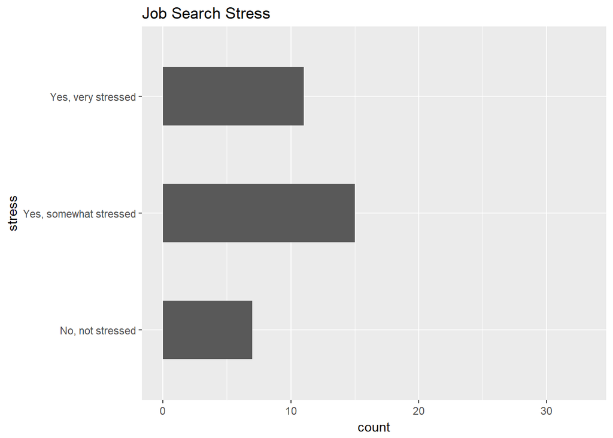

Our goal is therefore to illuminate the effectiveness of different job search resources so that students can allocate their time most productively. Our model focuses on making recommendations that minimize excess effort and time time spent job searching. These include recommendations about what skills you should develop in the long term and what resources you should use in the short term.

# Model

Our original model approached our question as a classification questions. Respondents were segmented into two groups: those who accepted a job offer in under 3 months of searching, and those who did not. We chose the 3 month cutoff because about half of respondents fell on one side and half on the other.

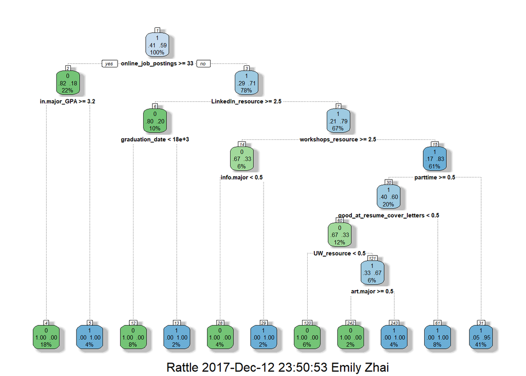

```r
og.model.data <- data %>%
  # reformat graduation data as date
  mutate(graduation_date = as.Date(graduation_date, "%m/%d/%Y")) %>%

  # split job type into 3 binary columns (1 = internship, 2 = part time, 3 = full time)
  mutate(fulltime = ifelse(Job_type == 3, 1, 0)) %>%
  mutate(parttime = ifelse(Job_type == 2, 1, 0)) %>%
  mutate(internship = ifelse(Job_type == 1, 1, 0)) %>%
  select(-Job_type) %>%

  # convert months to classification variable (0 = >3mo., 1 = <3mo.)
  mutate(Months = ifelse(Months <= 3, 1, 0)) %>%

  # split class standing into 5 binary columns
  mutate(freshman = ifelse(class_standing_ == 1, 1, 0)) %>%
  mutate(sophomore = ifelse(class_standing_ == 2, 1, 0)) %>%
  mutate(junior = ifelse(class_standing_ == 3, 1, 0)) %>%
  mutate(senior = ifelse(class_standing_ == 4, 1, 0)) %>%
  mutate(fifth.year = ifelse(class_standing_ == 5, 1, 0)) %>%
  mutate(alumni = ifelse(class_standing_ == 6, 1, 0)) %>%
  select(-class_standing_) %>%

  # remove test data
  # (filter out people just beginning job search (no job, searching for < 3 mo.))
  filter((has_position == 0 & Months == 0) | (None_of_these == 1 & Months == 0) | has_position == 1 | None_of_these == 0) %>%

  # remove factors that we don't want to predict on
  select(-None_of_these, -has_position)

# create decision tree
og.tree <- rpart(Months ~ .,
                 data = og.model.data, method = "class",
                 control=rpart.control(minbucket=1))

# plot tree
fancyRpartPlot(og.tree)
```

Our solution was to analyze only individuals who got offers in the first couple months of their job search under the assumption they would have only had the chance to utilize one strategy. We looked for a natural cutoff in the data but found none so four months was chosen arbitrarily. While this method prevents us from analyzing strategies that did not work it allows us to definitively point to the strategies that did work.

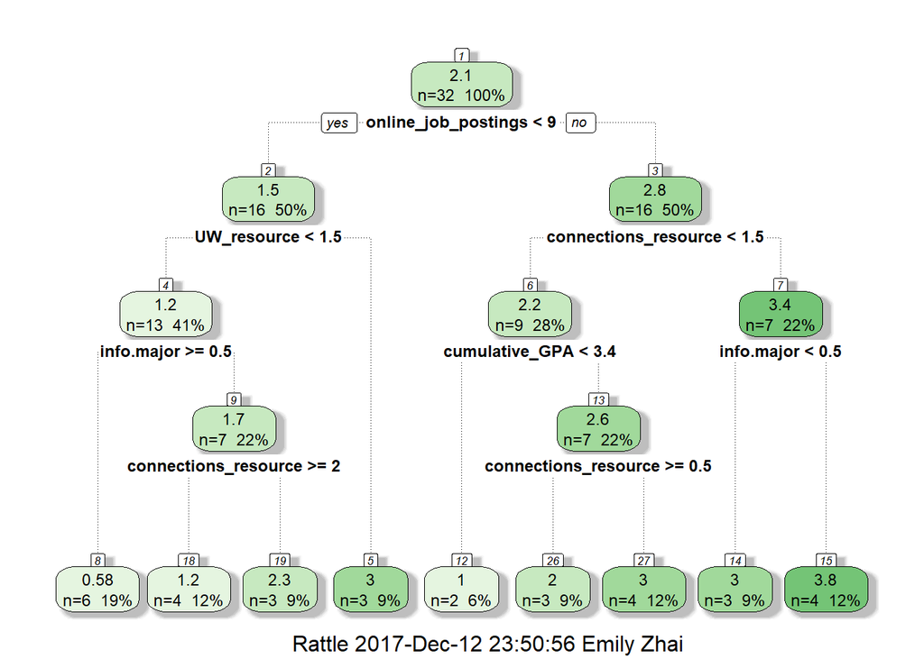

```r
revised.model.data <- data %>%
  # reformat graduation data as date
  mutate(graduation_date = as.Date(graduation_date, "%m/%d/%Y")) %>%

  # split job type into 3 binary columns (1 = internship, 2 = part time, 3 = full time)
  mutate(fulltime = ifelse(Job_type == 3, 1, 0)) %>%
  mutate(parttime = ifelse(Job_type == 2, 1, 0)) %>%
  mutate(internship = ifelse(Job_type == 1, 1, 0)) %>%
  select(-Job_type) %>%

  # split class standing into 5 binary columns
  mutate(freshman = ifelse(class_standing_ == 1, 1, 0)) %>%
  mutate(sophomore = ifelse(class_standing_ == 2, 1, 0)) %>%
  mutate(junior = ifelse(class_standing_ == 3, 1, 0)) %>%
  mutate(senior = ifelse(class_standing_ == 4, 1, 0)) %>%
  mutate(fifth.year = ifelse(class_standing_ == 5, 1, 0)) %>%
  mutate(alumni = ifelse(class_standing_ == 6, 1, 0)) %>%
  select(-class_standing_) %>%

  # get subset where job found in <= 4 months
  filter(Months <= 4) %>%

  # remove test data
  # (filter out people just beginning job search (no job, searching for < 3 mo.))
  filter((has_position == 0 & Months == 0) | (None_of_these == 1 & Months == 0) | has_position == 1 | None_of_these == 0) %>%

  # remove factors that we don't want to predict on
  select(-None_of_these, -has_position)

# create decision tree
revised.tree <- rpart(Months ~ ., data = revised.model.data, method = "anova", control=rpart.control(minbucket=2))

# plot decision tree
fancyRpartPlot(revised.tree)
```

# Additional Exploration

We did a lot of additional exploration on our dataset to supplement the model we created.

## Scatter Plot

First, we plotted scatter plot of a number of the months for job searching by a number of students at each type of job to determine when to stop job searching using the same method.

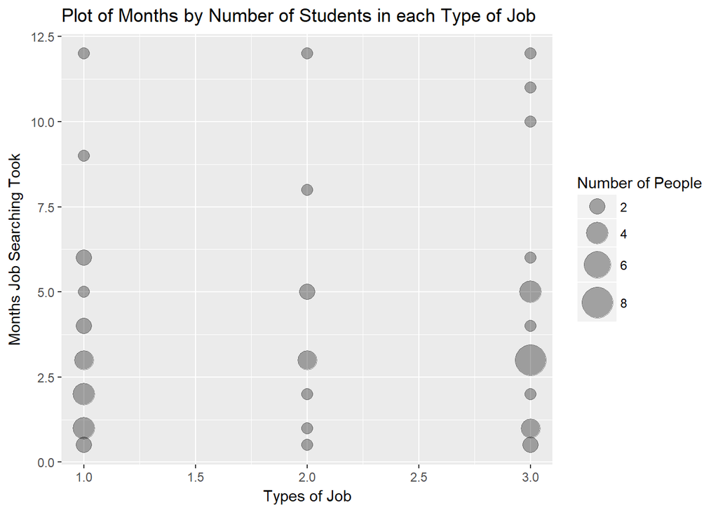

```r
ggplot(data = data) +
  geom_count(mapping = aes(x = Job_type, y = Months), alpha = 1/3) + scale_size_area(max_size = 10) +
  labs(title = "Plot of Months by Number of Students in each Type of Job",
       x = "Types of Job", y = "Months Job Searching Took", size = "Number of People")
```

## Linear Regression Model

In order to analyze the job search resources that offer highest rates of a job, we implemented linear regression model. Iterating through the variables, we ran simple linear regression model to discover linear relationships between each resource as an input variable and the months of job searching as an output variable.

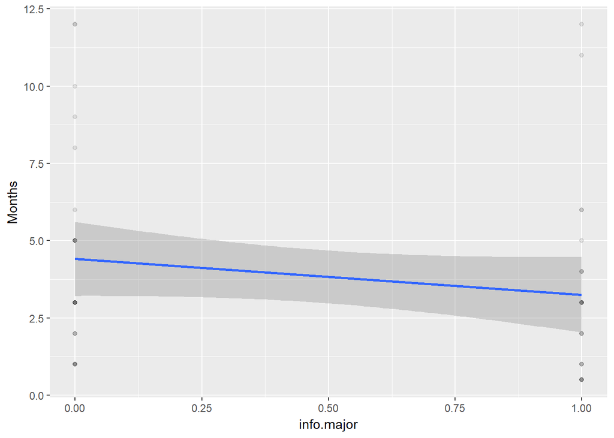

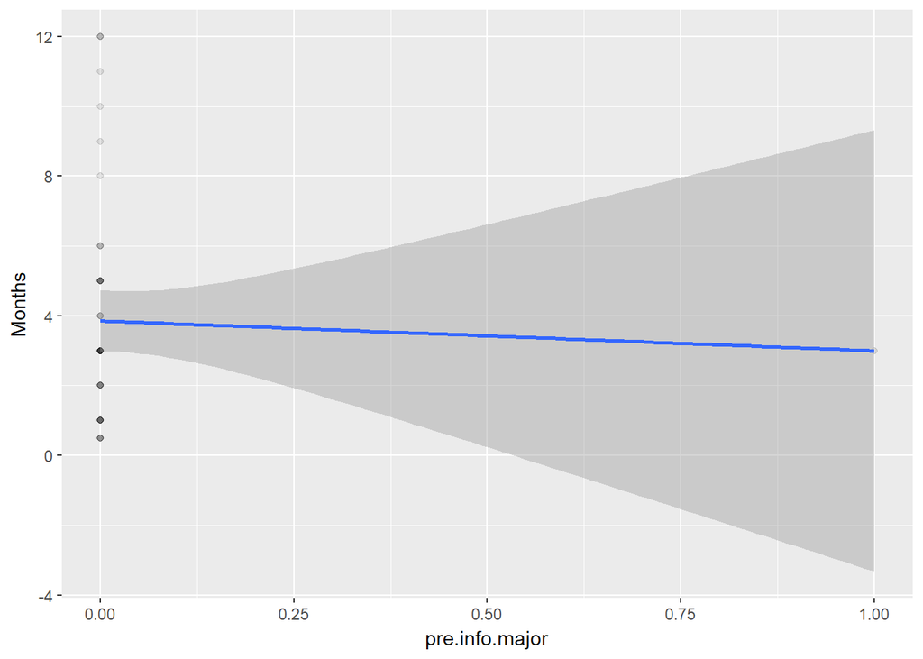

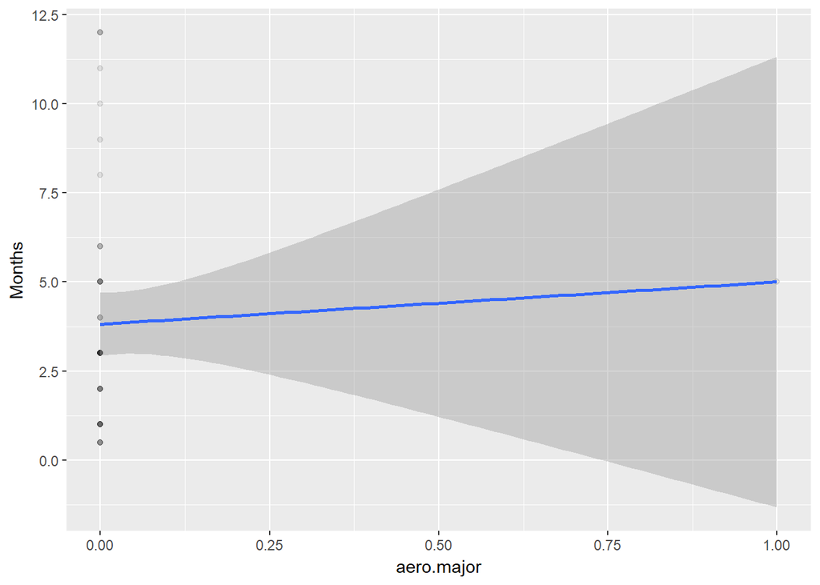

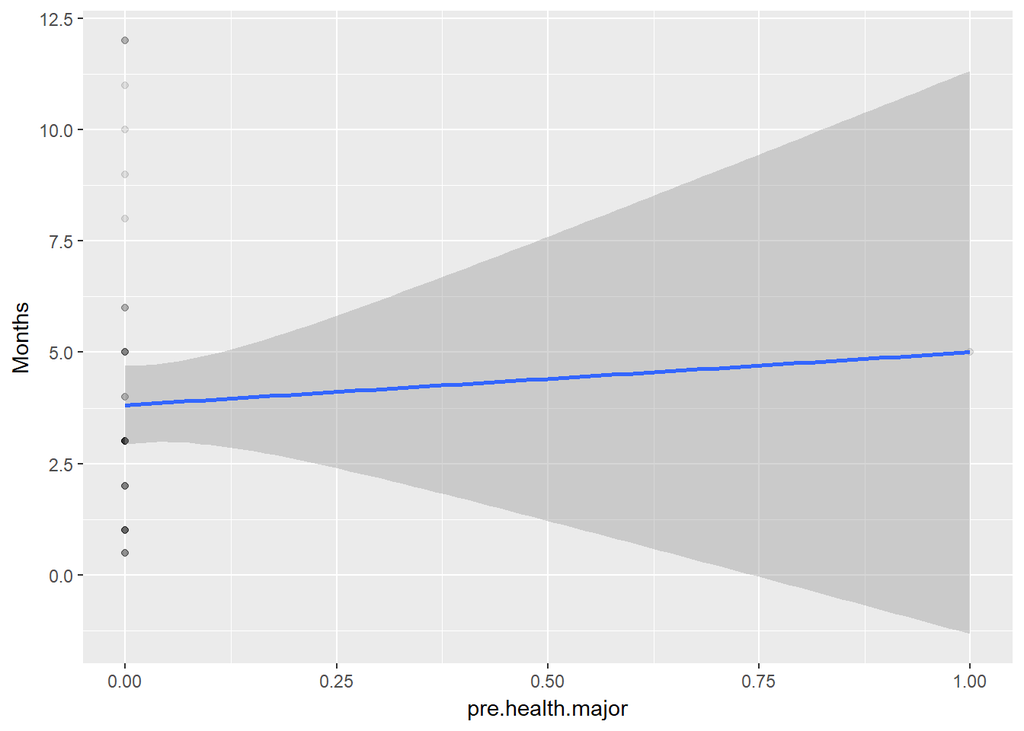

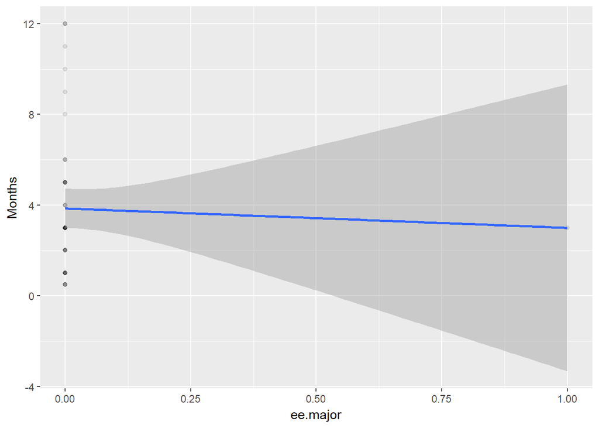

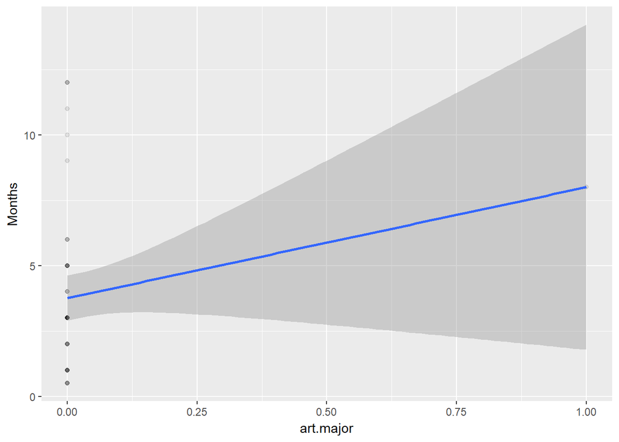

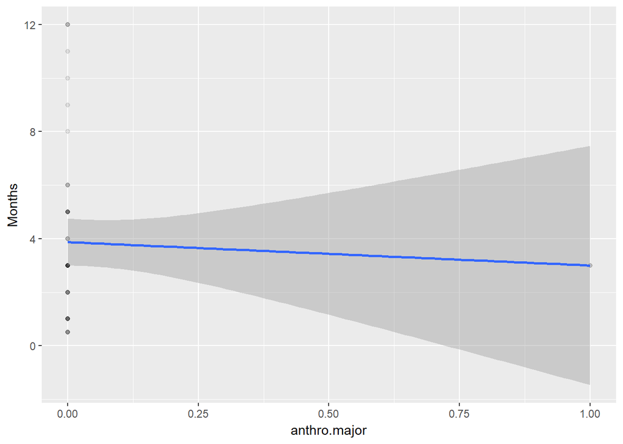

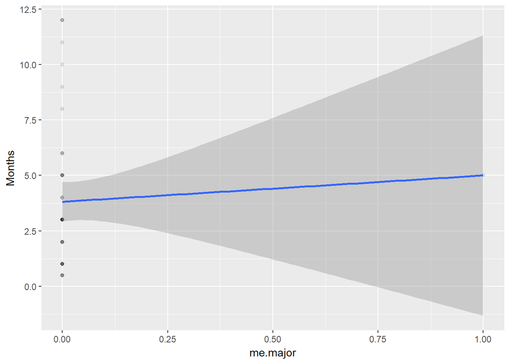

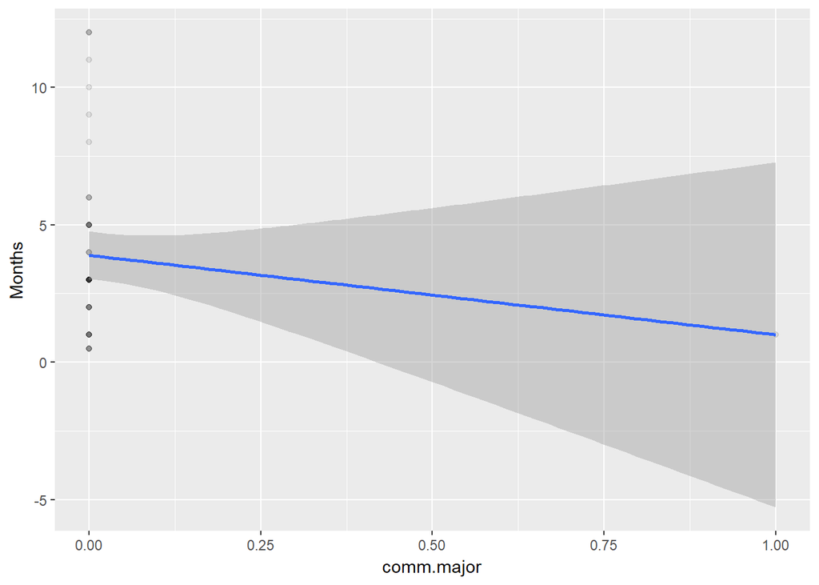

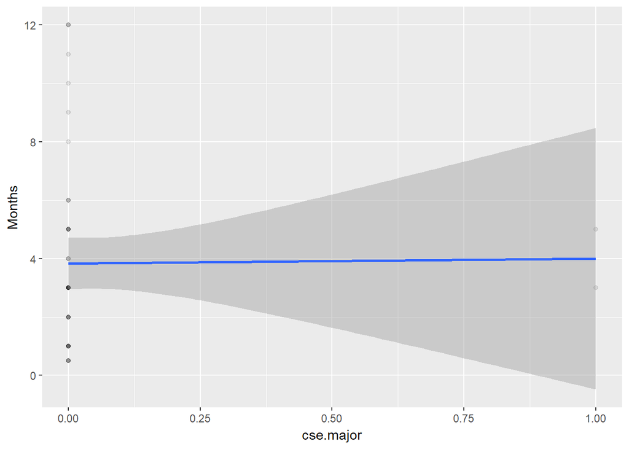

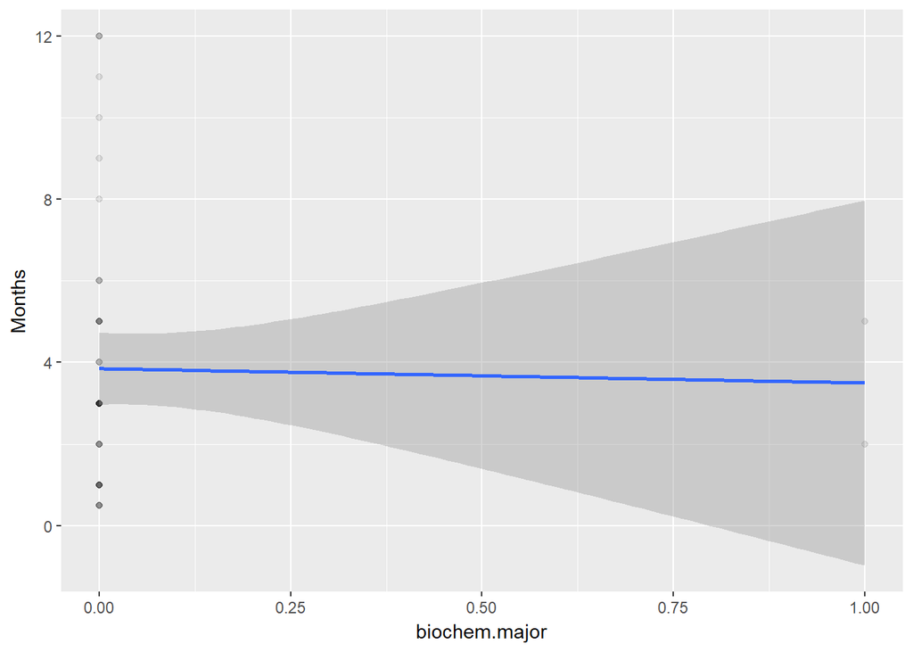

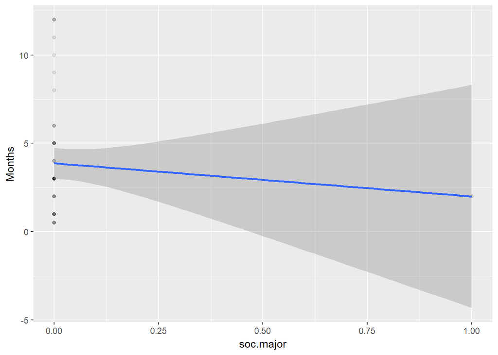

[59 more figures not shown]

```r
#linear regression for each factor against the outcome variable (months it takes to find job)
#internship = 1, part time = 2, full time = 3
#female = 1, male = 0
for (i in 1:ncol(data)){
  print(ggplot(data, aes(x = data[[i]], y = Months)) +
    geom_point(alpha = 0.1) +
    geom_smooth(method=lm) +
      labs(x = colnames(data)[i]))
}
```

According to the simple linear regression models of resources, too much time input on one resource extends the time of getting a job. However, utilizing employer campus visit, employer website resource, Huskyjobs, and connection decreases the time of receiving an offer.

## Additional Linear Regression

There was unusual trends in our linear regression that points doubt on our expectation: Better major GPA results in more time of getting a job while cumulative GPA has opposite trends. Of course, it is crucial to maintain high cumulative GPA for employment. However, it is not logical to argue that the higher major GPA postpones the duration of job searching. Therefore, we plotted additional GPA graphs with removed values of 0.0.

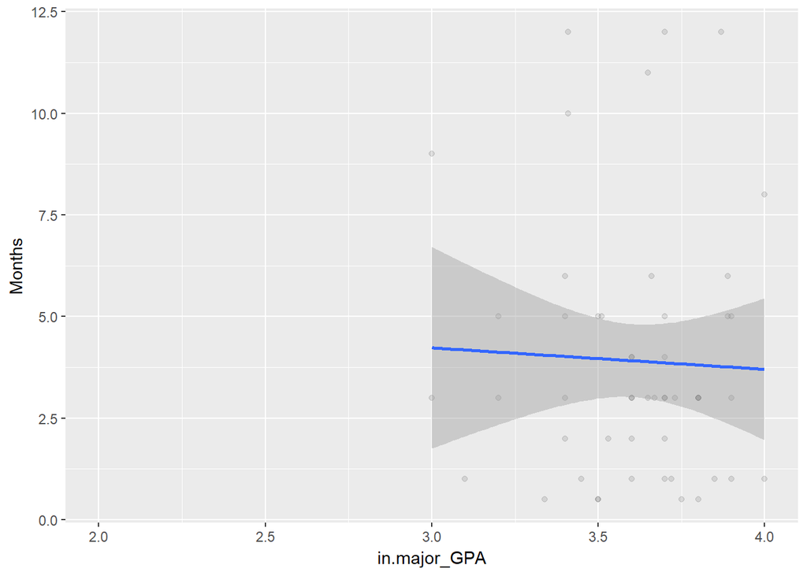

```r
#additional gpa graphs to remove values of 0.0 for GPA
ggplot(data, aes(x = in.major_GPA, y = Months)) +
  geom_point(alpha = 0.1 ) +
  xlim(2,4) +
  geom_smooth(method=lm)
```

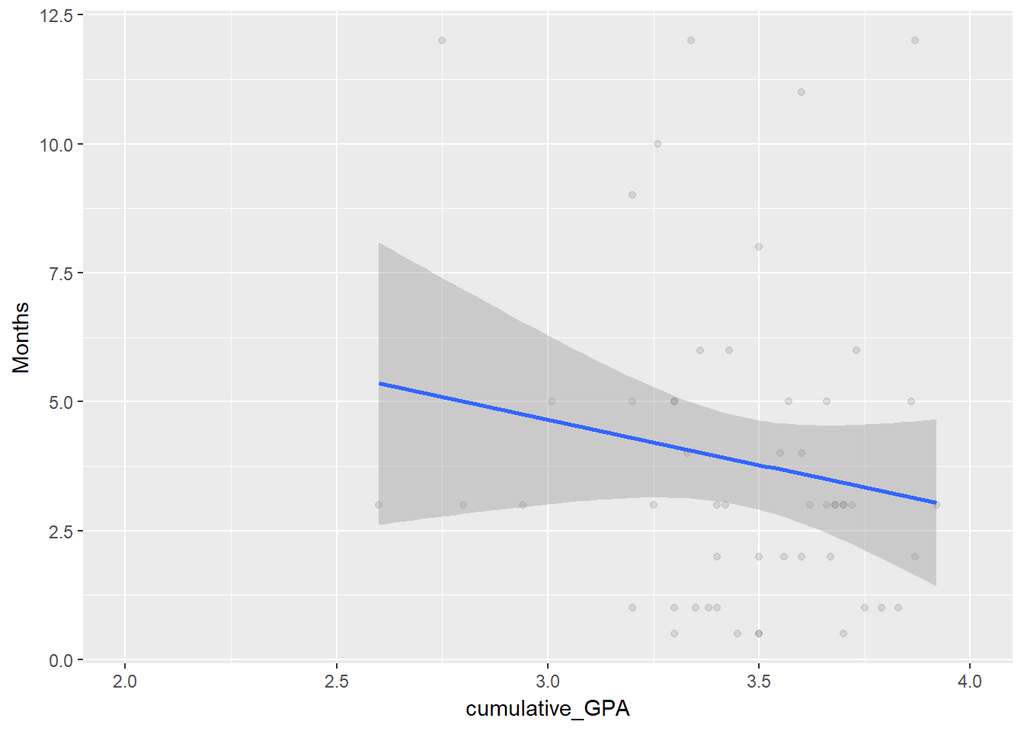

```r
ggplot(data, aes(x = cumulative_GPA, y = Months)) +
  geom_point(alpha = 0.1 ) +
  xlim(2,4) +
  geom_smooth(method=lm)
```

## Lasso Regression

For the multi-feature problem in linear regression, we used L1 regulation Lasso to model mean squared error.

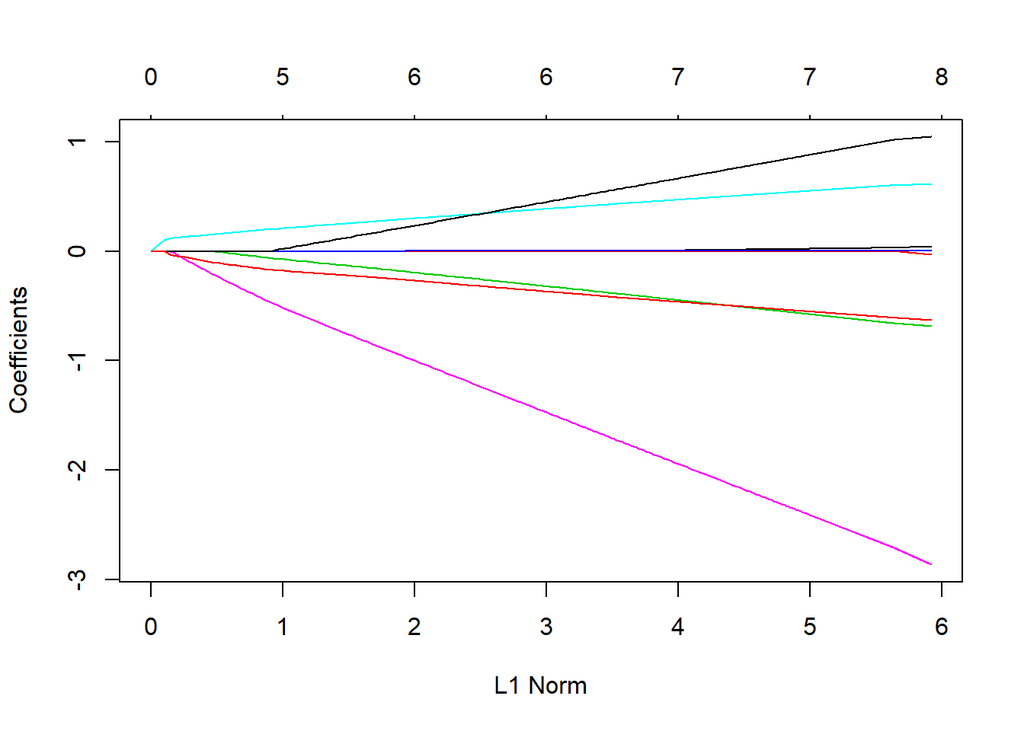

```r
month <- data[, "Months"]

# Create dataframe
df = data.frame(data$Months, data$resume_hrs, data$cover_letter_hours, data$self.confidence, data$online_job_postings, data$no_career_fairs, data$cumulative_GPA, data$in.major_GPA, data$internships)

x <- as.matrix(df[-1]) # Removes month
y <- as.matrix(df[, 1]) # Only month

# Plot Mean Squared Error Plot and Lasso path using glmnet
cvfit <- cv.glmnet(x, y,parallel=TRUE, standardize=TRUE, alpha=1, nlambda=1000)
fit <- glmnet(x, y, standardize=TRUE, alpha=1, nlambda=1000)
plot(fit)
```

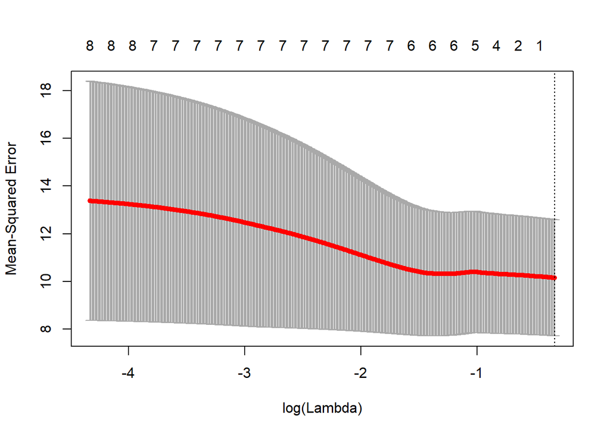

```r
plot(cvfit)
```

As lambda increases, the lasso removes more and more coefficients by setting them to zero. Also, there are two minima for graph: around log(lambda) of -1.3 with the number of non-zero coefficient 6 and the log(lambda) of 0 with the number of non-zero coefficient 1. Thus, the model is telling less number of factors makes better result for success in employment.

## Coefficient of Lasso Regression

We analyzed the coefficient of lasso model in order to observe the pattern.

```r
fit.coef <- coef(fit)
head(fit.coef, 5)
```

```
## 5 x 513 sparse Matrix of class "dgCMatrix"
```

```
##    [[ suppressing 513 column names 's0', 's1', 's2' ... ]]
```

[output not shown]

[output cut: 911 more lines]

[output not shown]

The coefficient of lasso model shows increasing pattern of a number of career fairs student attended, despite decreasing pattern of cumulative GPA and number of internships. The number of career fairs, cumulative gpa, and internship is major factors that affect the result of employment.

## Scatter Plot

We plotted the observation from the coefficeint of lasso model

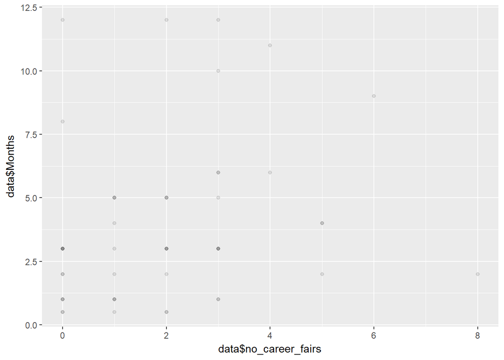

```r
ggplot(data, aes(x= data$no_career_fairs, y = data$Months)) + geom_point(alpha = .1)
```

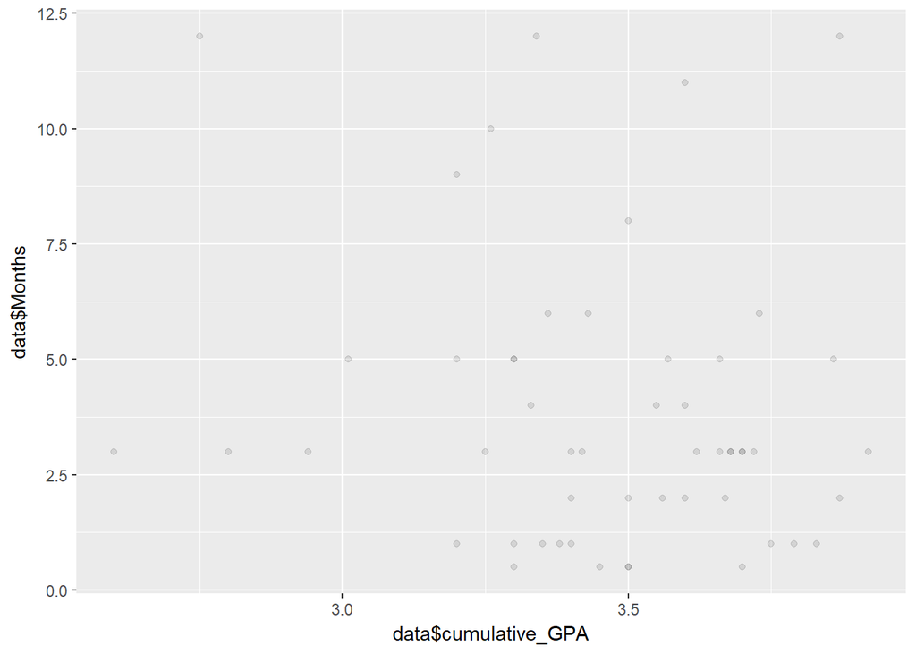

```r
ggplot(data, aes(x= data$cumulative_GPA, y = data$Months)) + geom_point(alpha = .1)
```

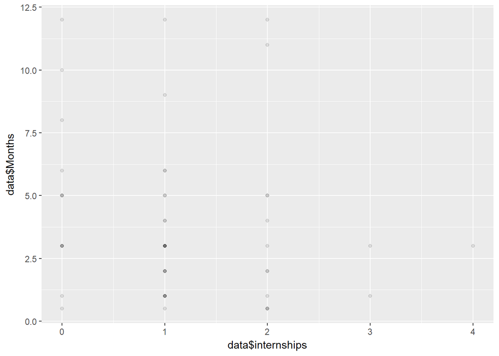

```r
ggplot(data, aes(x= data$internships, y = data$Months)) + geom_point(alpha = .1)
```

# Results

From our analysis we’re able to make a few recommendations: * Avoid overusing/relying too heavily on online resources like LinkedIn, online job postings, etc.